# Individual3

Shellie Jurchisin

3/2/2021

```r
library(dplyr)
library(tidyverse)
```

```r
library(classdata)
library(ggplot2)
```

```r
dat <- readxl::read_xls('GSS.xls')
dat<- rename(dat, 'Year' = 'Gss year for this respondent')
dat<- rename(dat, 'HappyCt' = 'General happiness')
dat<- rename(dat, 'PoliticalParty' = 'Political party affiliation')
dat<- rename(dat, 'Gender' = 'Respondents sex')
dat<- rename(dat, 'Education' = 'Highest year of school completed')
dat<- rename(dat, 'Divorced' = 'Ever been divorced or separated')
dat<- rename(dat, 'MaritalStatus' = 'Marital status')
dat<- rename(dat, 'LaborStatus' = 'Labor force status')
dat<- rename(dat, 'ID' = 'Respondent id number')
dat<- rename(dat, 'Ballot' = 'Ballot used for interview')
```

#1)

```r
dat %>%
  group_by(MaritalStatus) %>%
  summarize(avg_edu = mean(as.numeric(Education), na.rm=TRUE)) %>%
  arrange(avg_edu)
```

```
## # A tibble: 7 x 2
##   MaritalStatus avg_edu
##   <chr>           <dbl>
## 1 Widowed          11.2
## 2 Separated        11.9
## 3 Married          13.0
## 4 Divorced         13.1
## 5 Never married    13.4
## 6 No answer        15.5
## 7 <NA>            NaN
```

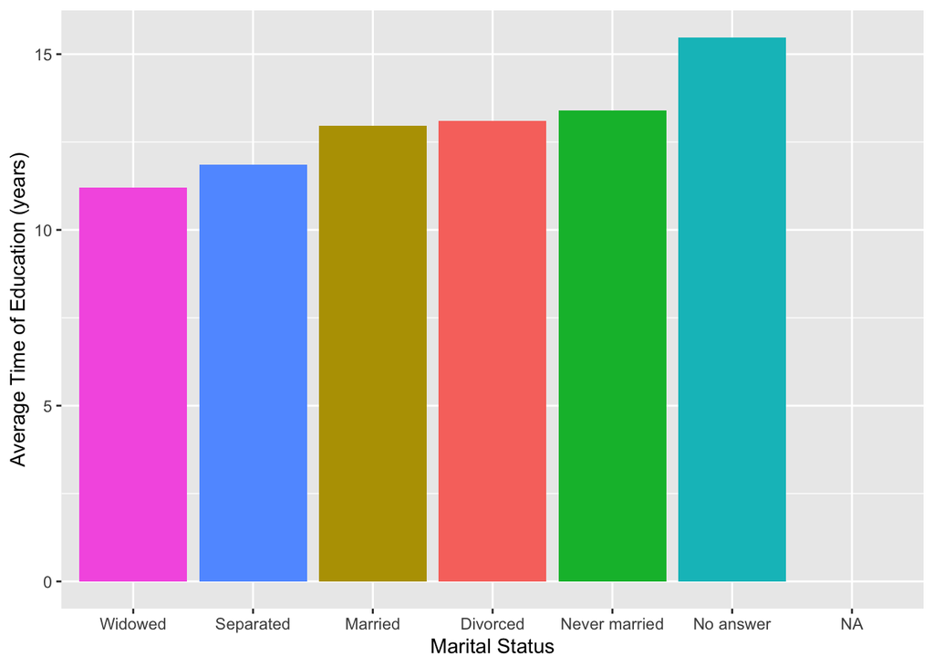

```r
dat %>%
  group_by(MaritalStatus) %>%
  summarize(avg_edu = mean(as.numeric(Education), na.rm=TRUE)) %>%
  ggplot(aes(x=reorder(MaritalStatus, avg_edu), weight=avg_edu))+geom_bar(aes(fill=MaritalStatus), show.legend = FALSE) + xlab("Marital Status") + ylab("Average Time of Education (years)")
```

#Explanation: We can see that people who put no answer for their martial status on average had the highest amount of education (15.5 years). Those who responded with never married, divorced, and married all had very similar levels of education (13.3 years, 13.1 years, 12.9 years). This tells us that someones education level and martial status aren’t heavily correlated.

#2)

```r
better_edu <- dat %>%
  group_by(MaritalStatus) %>%
  filter(Education > mean(as.numeric(Education), na.rm=TRUE))
str(better_edu)
```

```
## tibble [38,535 × 10] (S3: grouped_df/tbl_df/tbl/data.frame)
##  $ Year          : num [1:38535] 1972 1972 1972 1972 1972 ...
##  $ HappyCt       : chr [1:38535] "Not too happy" "Not too happy" "Pretty happy" "Not too happy" ...
##  $ PoliticalParty: chr [1:38535] "Ind,near dem" "Not str democrat" "Ind,near dem" "Ind,near dem" ...
##  $ Gender        : chr [1:38535] "Female" "Female" "Male" "Male" ...
##  $ Education     : chr [1:38535] "16" "17" "14" "16" ...
##  $ Divorced      : chr [1:38535] "Not applicable" "No" "Not applicable" "Not applicable" ...
##  $ MaritalStatus : chr [1:38535] "Never married" "Married" "Never married" "Never married" ...
##  $ LaborStatus   : chr [1:38535] "Working fulltime" "Working fulltime" "Working fulltime" "Working fulltime" ...
##  $ ID            : num [1:38535] 1 4 6 8 11 12 13 14 15 16 ...
##  $ Ballot        : chr [1:38535] "Not applicable" "Not applicable" "Not applicable" "Not applicable" ...
##  - attr(*, "groups")= tibble [6 × 2] (S3: tbl_df/tbl/data.frame)
##   ..$ MaritalStatus: chr [1:6] "Divorced" "Married" "Never married" "No answer" ...
##   ..$ .rows        : list<int> [1:6]
##   .. ..$ : int [1:4185] 8 45 65 66 87 88 97 115 138 202 ...
##   .. ..$ : int [1:20024] 2 5 6 7 9 10 11 12 13 15 ...
##   .. ..$ : int [1:7133] 1 3 4 14 20 24 30 41 43 47 ...
##   .. ..$ : int [1:19] 13923 15406 16838 18581 27854 29062 29264 29708 29806 29821 ...
##   .. ..$ : int [1:1857] 68 71 92 118 119 121 164 172 173 223 ...
##   .. ..$ : int [1:5317] 25 42 74 83 85 100 131 145 149 150 ...
##   .. ..@ ptype: int(0)
##   ..- attr(*, ".drop")= logi TRUE
```

#3)

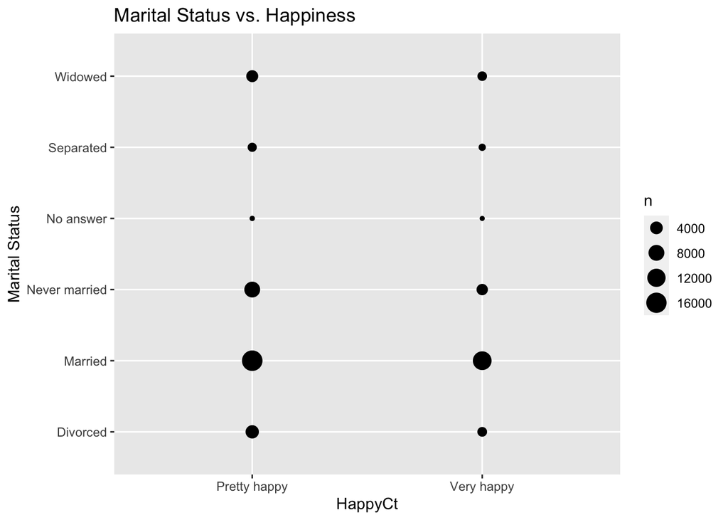

```r
HappyCt <- filter(dat, HappyCt == 'Very happy' | HappyCt == 'Pretty happy')
p <- ggplot(HappyCt, aes(x = HappyCt, y = MaritalStatus)) + geom_count()
p + ggtitle('Marital Status vs. Happiness') + xlab('HappyCt') + ylab('Marital Status')
```

#numerical

```r
HappyCt %>% count(MaritalStatus)
```

```
## # A tibble: 6 x 2
##   MaritalStatus     n
## * <chr>         <int>
## 1 Divorced       6180
## 2 Married       29342
## 3 Never married 10686
## 4 No answer        16
## 5 Separated      1487
## 6 Widowed        4675
```

#Explanation: It looks like people who are married tend to be more happy (pretty happy & very happy) while those who are separated, divorced, or widowed don’t appear to be as happy.

#4)

```r
h = dat %>% group_by(`MaritalStatus`, `PoliticalParty`) %>%
  filter(`HappyCt` == "Pretty happy" | `HappyCt` == "Very happy") %>%
  summarize(`HappyCt.n` = n()) %>%
  mutate(`HappyCt.per2` = `HappyCt.n`/ sum(`HappyCt.n`))
```

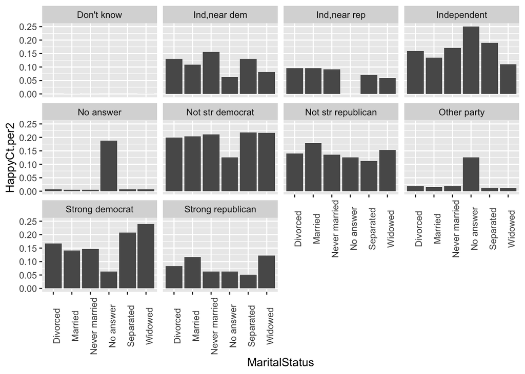

```r
h %>%
  ggplot(aes(x = `MaritalStatus`, y = `HappyCt.per2`)) +
  geom_bar(stat = 'identity') + theme(axis.text.x = element_text(angle = 90)) +
  facet_wrap(~`PoliticalParty`)
```

#5)

```r
dat<-dat %>%mutate(Education = as.numeric(Education))
EduMS <- dat %>%
    group_by(MaritalStatus) %>%
    summarise(Education_mean = mean(Education, na.rm = TRUE)) %>%
    arrange(Education_mean)
EduMS
```

```
## # A tibble: 7 x 2
##   MaritalStatus Education_mean
##   <chr>                  <dbl>
## 1 Widowed                 11.2
## 2 Separated               11.9
## 3 Married                 13.0
## 4 Divorced                13.1
## 5 Never married           13.4
## 6 No answer               15.5
## 7 <NA>                   NaN
```

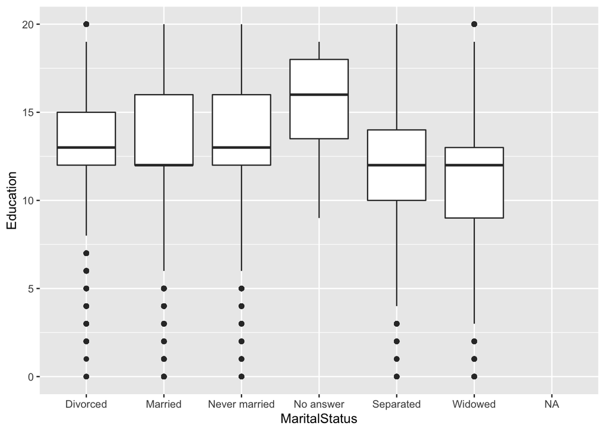

```r
ggplot(dat, aes(x = MaritalStatus, y = Education)) + geom_boxplot()
```

#6)